# BA 830 Experiment Report

Cohort A Team 8: Huiying Ba, Danting Huang, Ziqin Ma, Jiao Sun, Senbo Zhang

1. Your causal question of interest.

We are interested in the potential causal effects of listening to music on instant memory.

2. Your experimental design and what data you collected.

Our null hypothesis is that listening to music has no causal effect on people’s instant memory.

3. Why you chose the experiment design.

4. Summary statistics about the data.
1. Load the data
2. Summary statistics

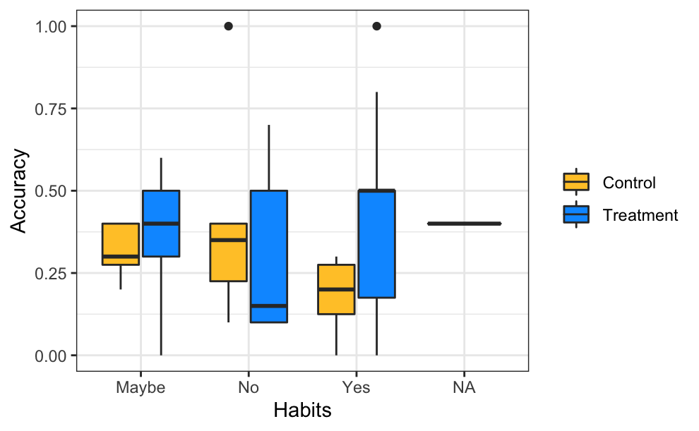

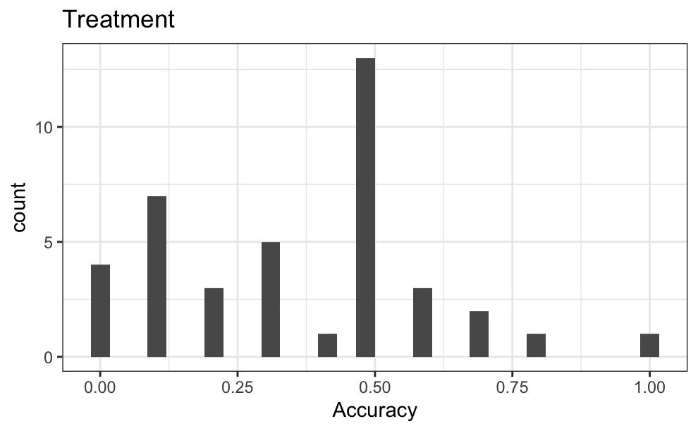

```r
t = tableF[Treatment == 1]
ggplot(t) +
  geom_histogram(aes(Accuracy)) +
  labs(title = "Treatment") +
  theme_bw()
```

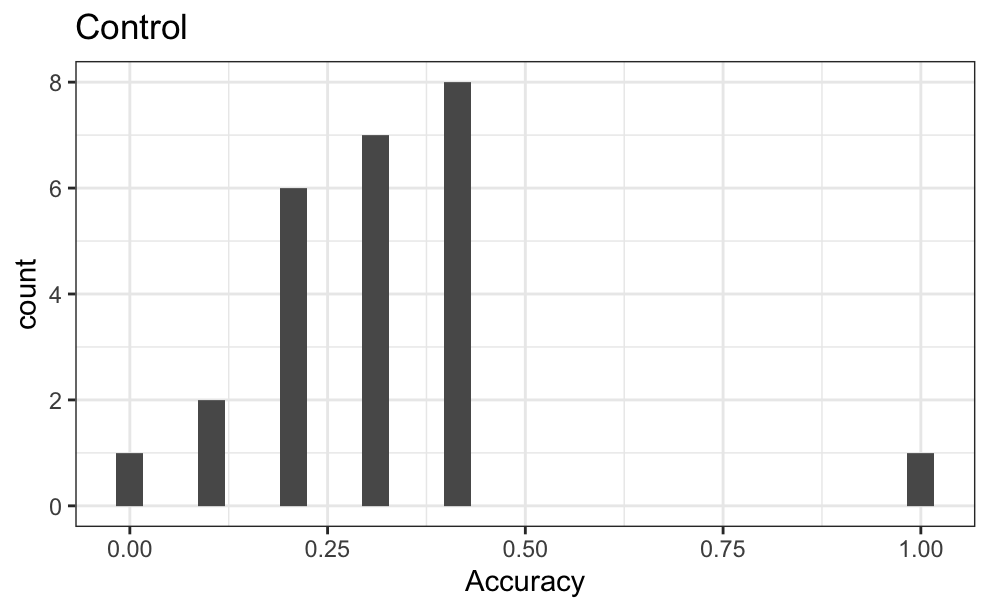

```r
c = tableF[Treatment == 0]
ggplot(c) +
  geom_histogram(aes(Accuracy)) +
  labs(title = "Control") +
  theme_bw()
```

5. Treatment effects

```r
reg1 = felm(Accuracy ~ Treatment, data = tableF)
summary(reg1)
```

```
Call:
   felm(formula = Accuracy ~ Treatment, data = tableF)

Residuals:
    Min      1Q  Median      3Q     Max
-0.3675 -0.1675 -0.0080  0.1325  0.6920

Coefficients:
            Estimate Std. Error t value Pr(>|t|)
(Intercept)  0.30800    0.04469   6.891 3.09e-09 ***
Treatment    0.05950    0.05697   1.044      0.3
---
Signif. codes:  0 ‘***’ 0.001 ‘**’ 0.01 ‘*’ 0.05 ‘.’ 0.1 ‘ ’ 1

Residual standard error: 0.2235 on 63 degrees of freedom
  (36 observations deleted due to missingness)
Multiple R-squared(full model): 0.01702   Adjusted R-squared: 0.001414
Multiple R-squared(proj model): 0.01702   Adjusted R-squared: 0.001414
F-statistic(full model):1.091 on 1 and 63 DF, p-value: 0.3003
F-statistic(proj model): 1.091 on 1 and 63 DF, p-value: 0.3003
```

```r
# stargazer(reg1, type = "text", out = "reg1.txt")
```

```r
reg2 = felm(Accuracy ~ Treatment | Q14, data = tableF)
summary(reg2)
```

```
Call:
   felm(formula = Accuracy ~ Treatment | Q14, data = tableF)

Residuals:
     Min       1Q   Median       3Q      Max
-0.38553 -0.15787 -0.00128  0.13399  0.69872

Coefficients:
          Estimate Std. Error t value Pr(>|t|)
Treatment  0.06745    0.06091   1.107    0.273

Residual standard error: 0.2284 on 60 degrees of freedom
  (37 observations deleted due to missingness)
Multiple R-squared(full model): 0.02128   Adjusted R-squared: -0.02765
Multiple R-squared(proj model): 0.02003   Adjusted R-squared: -0.02897
F-statistic(full model):0.4349 on 3 and 60 DF, p-value: 0.7288
F-statistic(proj model): 1.226 on 1 and 60 DF, p-value: 0.2726
```

```r
# stargazer(reg2, type = "text", out = "reg2.txt")
```

Found that whether participants listen to music when studying is not a fixed effect in this experiment.

```r
summary(felm(Accuracy ~ Treatment+Q14, data = tableF))
```

```
Call:
   felm(formula = Accuracy ~ Treatment + Q14, data = tableF)

Residuals:
     Min       1Q   Median       3Q      Max
-0.38553 -0.15787 -0.00128  0.13399  0.69872

Coefficients:
            Estimate Std. Error t value Pr(>|t|)
(Intercept)  0.31809    0.06358   5.003 5.23e-06 ***
Treatment    0.06745    0.06091   1.107    0.273
Q14No       -0.01681    0.07428  -0.226    0.822
Q14Yes      -0.02766    0.07123  -0.388    0.699
---
Signif. codes:  0 ‘***’ 0.001 ‘**’ 0.01 ‘*’ 0.05 ‘.’ 0.1 ‘ ’ 1

Residual standard error: 0.2284 on 60 degrees of freedom
  (37 observations deleted due to missingness)
Multiple R-squared(full model): 0.02128   Adjusted R-squared: -0.02765
Multiple R-squared(proj model): 0.02128   Adjusted R-squared: -0.02765
F-statistic(full model):0.4349 on 3 and 60 DF, p-value: 0.7288
F-statistic(proj model): 0.4349 on 3 and 60 DF, p-value: 0.7288
```

Q14 is not a covariate either.

```r
summary(felm(Accuracy ~ Treatment|Q13, data = tableF))
```

```
Call:
   felm(formula = Accuracy ~ Treatment | Q13, data = tableF)

Residuals:
     Min       1Q   Median       3Q      Max
-0.36435 -0.16721 -0.00178  0.13565  0.69822

Coefficients:
          Estimate Std. Error t value Pr(>|t|)
Treatment  0.06257    0.05870   1.066    0.291

Residual standard error: 0.2267 on 61 degrees of freedom
  (37 observations deleted due to missingness)
Multiple R-squared(full model): 0.01931   Adjusted R-squared: -0.01285
Multiple R-squared(proj model): 0.01828   Adjusted R-squared: -0.0139
F-statistic(full model):0.6004 on 2 and 61 DF, p-value: 0.5518
F-statistic(proj model): 1.136 on 1 and 61 DF, p-value: 0.2907
```

Q13 is not a fixed effect.

6. Limitations of your study.

[We had no control over the experiment process]

Example:

- possible cheating in exriment
- spillover
- participants intentionally skipped the instructions; did not take is seriously
- memorizing time may be different

[earbuds, location, volume]

[sample size too small]